# 大學生延畢的現象與探討

期末報告

社會二 406330714 袁東暉

六月 17, 2019

# 1 現象與探討

## 1.1 現象

- 依教育部統計，105學年大專校院延修生總計4.8萬人，較104學年增加1.4%，其中男性2.9 萬人(占60.3%)，較 104 學年減 0.9％，女性1.9 萬人(占39.7%)，則增5%。

## 1.2 延畢的原因

- 在初探台灣大學生延畢現象(林莉閔，2009)這篇論文中，作者設立經濟模型說明大學生延畢的原因，包括役期縮短、失業率提高、考研究所、雙主修或輔修的好處提高、在校資源增加、家長支持度提升、以及延畢風氣的影響等七個因素對延畢現象推波助瀾的效果。

## 1.3 延畢的後果

- 坊間多位求職專家表示，延畢生給業者的印象多為在校成績不佳、表現不夠優秀，甚至不敢面對就業市場壓力者，企業任用的意願常打折扣且據研究顯示，學生一旦選擇延畢，個人專業能力通常並未隨之增加，反因個人求職年齡愈大，更難以與應屆畢業生競爭，求職將轉趨困難。

# 2 個人因素

## 2.2 資料來源以及作圖方法

- 資料網址：https://depart.moe.edu.tw/ed4500/cp.aspx?n=1B58E0B736635285&s=D04C74553DB60CAD，裡的近年大專校院學士班以下延修生人數(90～107 學年度)
- 這一個問題我打算使用折線圖，以及長條圖，因為可以充份反應隨著時間，延畢的人數的變化，也能從中看出差異。

# 3 相關文獻

初探台灣大學生延畢現象(林莉閔，2009)這篇論文中，作者發現2000~2008年來台灣大專校院日間部全體學生延畢率在15-17%之間，男學生延畢率為17-23%且約為女學生的兩倍。全體學生延畢率以一般體系的公立學校最高約近20%，而公立學校女學生的延畢率則是遠高出私立學校3-5%的水準；其中，男學生延畢率以一般體系的私立學校最高。

# 4 Rcode

## 4.1 code

```r
library(tidyverse)
library(ggthemes)
library(readxl)

windowsFonts(A = windowsFont("微軟正黑體")) #改字體
multiplot <- function(..., plotlist=NULL, file, cols=1, layout=NULL) #建一個函數
{
  library(grid)
  plots <- c(list(...), plotlist)
  numPlots = length(plots)

  if (is.null(layout))
  {
    layout <- matrix(seq(1, cols * ceiling(numPlots/cols)),
                     ncol = cols, nrow = ceiling(numPlots/cols))
  }
  if (numPlots==1)
  {
    print(plots[[1]])
  }
  else
  {
    grid.newpage()
    pushViewport(viewport(layout = grid.layout(nrow(layout), ncol(layout))))

    for (i in 1:numPlots)
    {
      matchidx <- as.data.frame(which(layout == i, arr.ind = TRUE))
      print(plots[[i]], vp = viewport(layout.pos.row = matchidx$row,
                                      layout.pos.col = matchidx$col))
    }
  }
}

ydh <- read_xlsx("C:/Users/User/fju/Data visualization/weak16/Data/ydh.xlsx")
View(ydh)
```

## 4.2 圖表1

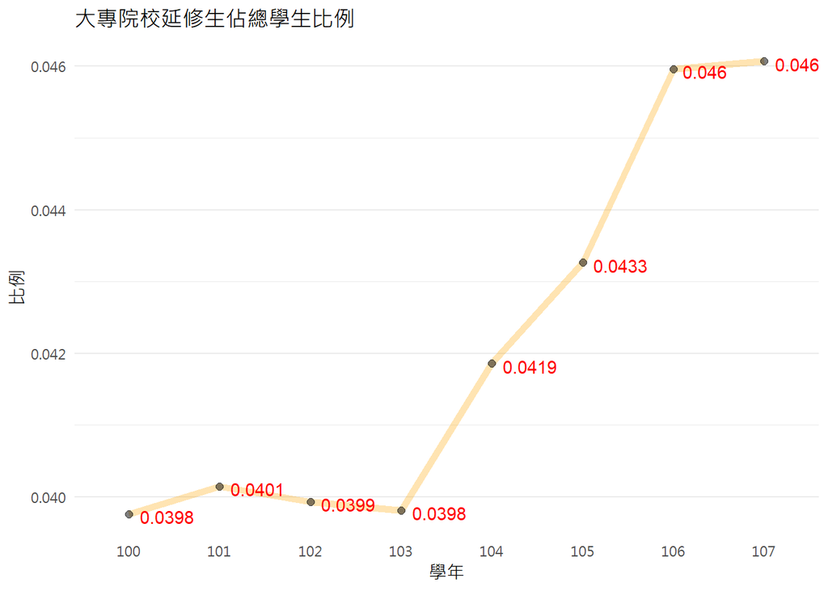

```r
q <- ggplot(ydh[1:8,],
            aes(x = year, y = dpct, group = 1))

q + geom_line(color = alpha("orange",.3), size = 2) +
  geom_point(shape = 21, size = 2, fill = "black", alpha = 0.5) +
  labs(x = "學年", y = "比例", title = "大專院校延修生佔總學生比例") +
  theme_minimal() +
  theme(panel.grid.major.x =  element_blank(),
        text = element_text(family = "A")) +
  geom_text(aes(label = round(dpct,4)), vjust = 0.7, hjust = -0.2, show.legend = F, color = "red")
```

此圖表顯示100年到107年全台延修生佔全台灣學生總人數的比例，我們可以看到在103~106年間大幅增加0.6個百分點。

## 4.3 圖表2

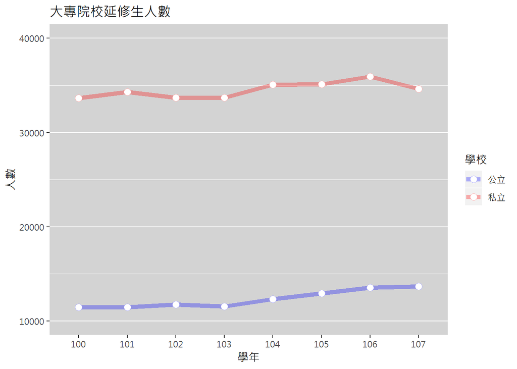

```r
p <- ggplot(ydh,
            aes(x = year, y = dpp, color = schoolp))

p + geom_line(aes(group = schoolp),size=2) +
  geom_point(shape = 21, size = 3, fill = "white") +
  theme(panel.grid.major.x = element_blank(), text = element_text(family = "A"),
        panel.background = element_rect(fill = "lightgray")) +
  labs(x = "學年", y = "人數", color = "學校",
       title = "大專院校延修生人數") +
  ylim(10000,40000) +
  scale_color_manual(values = alpha(c("blue","red"),.3))
```

## 4.4 圖表3

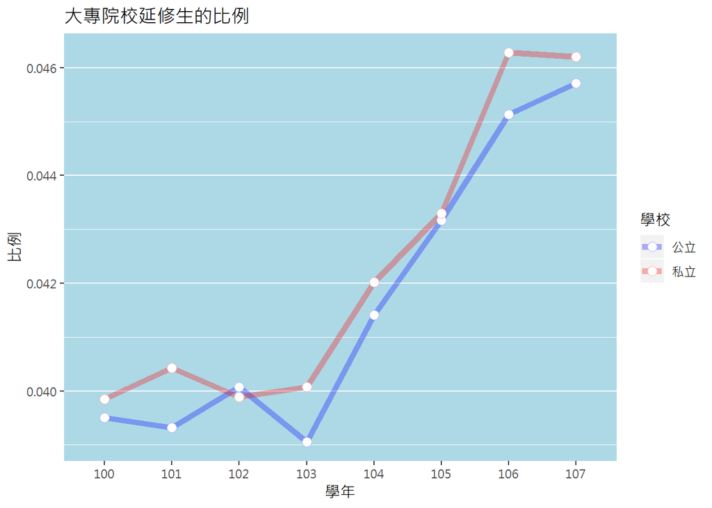

```r
m <- ggplot(data = ydh,
            mapping = aes(x = year, y = pct, color = schoolp))

m + geom_line(aes(group = schoolp),size=2) +
  geom_point(shape = 21, size = 3, fill = "white") +
  theme(panel.grid.major.x =  element_blank(), text = element_text(family = "A"),
        panel.background = element_rect(fill = "lightblue")) +
  labs(x = "學年", y = "比例", title = "大專院校延修生的比例", color = "學校") +
  scale_color_manual(values = alpha(c("blue","red"),.3))
```